# Car Sales

```r
library(mosaic)
library(tidyverse)
library(pander)
library(ggplot2)
library(DT)
library(car)
mycar <- c(60,16)
subaru <- data.frame(
  mileage = c(119,59,43,49,29,.01,82.8,165,123,195,203,8,.01,108,155,50,181,194,.01,.6),
  price = c(8.5,20,25,27.7,33.6,35.2,19,13,5,3,1.9,24,40.3,16.6,4.3,14.2,9,5,30.5,37),
  model = c(2012,2017,2018,2021,2022,2023,2018,2007,2006,2001,1995,2019,2023,2018,2009,2011,2012,2014,2023,2022)
)
```

In 2014, my parents found a deal on a car so good that they flew 3 states over and drove the car back. When I was younger that seemed a little extreme, but now let’s look back and see how that *2012 Subaru Legacy* holds up in price:

### Summary

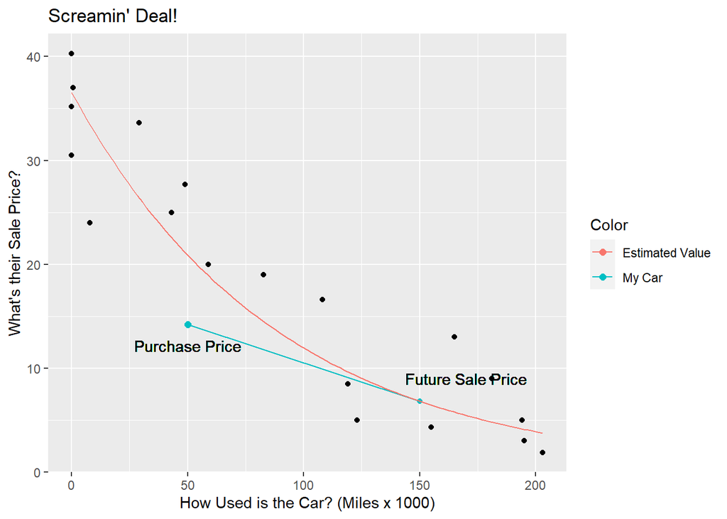

```r
sub.lm<-lm(price~mileage,data=subaru)
#boxCox(sub.lm)
sqrt.lm <- lm(sqrt(price)~mileage,data=subaru)
log.lm <- lm(log(price)~mileage,data=subaru)
b.sqrt <- coef(sqrt.lm)
b.log <- coef(log.lm)
#exp(b.log[1]+b.log[2]*150)
saleslope <- (14.2-7)/(170-50)
ggplot(subaru,aes(x=mileage,y=price)) +geom_point() +
  geom_point(aes(x=50,y=14.2, color='My Car'),size=2) +
  geom_text(aes(x=50, y=12.2), label='Purchase Price') +
  geom_text(aes(x=170,y=9),label='Future Sale Price') +
  geom_segment(aes(y=14.2,x=50,xend=150,yend=6.828624,color='My Car')) +
  geom_point(aes(y=6.828624,x=150,color='My Car')) +
  #stat_function(fun=function(x) (b.sqrt[1]+b.sqrt[2]*x)^2,aes(color='sqrt(Y)')) +
  stat_function(fun=function(x) exp(b.log[1]+b.log[2]*x),aes(color='Estimated Value')) +
  #geom_text(aes(x=100,y=8),label='6 cents per mile') +
  labs(x='How Used is the Car? (Miles x 1000)',y='What\'s their Sale Price?',title='Screamin\' Deal!',color='Color')
```

150,000 miles is where I estimate that the car becomes old enough that the cost of maintenance is more than the drop in resale value per mile. My parents bought it for 14K, and driving it for another 100K miles will create an estimated resale value of 6.8K, meaning that we spent $7,200 in total to drive for 100K miles.